# Stroop Test

Tarique Hasheem

12/20/2017

#### Background

In psychology the Stroop effect is an interesting occurrence that demonstrate reaction times of participants who are asked to say the color of a word that’s presented to them out loud. For example red , green known as *congruent words* where the color and words match. The opposite are *incongruent words* where the words are not in the color they appear, for example blue or grey. The results are fascinating, reaction times to incongruent words are slower than congruent words. In our project we’ll investigate the Stroop effect using statistics to help uncover some of our questions.

#### Questions for Investigation

#### 1. What is our independent variable? What is our dependent variables?

Our independent variable are the colors and our dependent variable are reaction time.

#### 2.A. What is an appropriate set of hypotheses?

μ = population mean

There is no difference in population means of response time under incongruent and congruent scenarios, which can be mathematically represented as H0: μC = μI.

There is a difference in population means of response time under incongruent and congruent scenarios, which can be mathematically represented as Ha: μC ≠ μI.

##### 2.B. What kind of statistical test do you expect to perform?

The dependent t-tests compares the mean of two groups to determine whether there is a statistically significant difference between them. Dependent test indicates that the same participant have been tested more than once.  
T-test’s are great when we don’t know the population parameters. We’re interested in a two-tailed test to simply test for the possibility that of the relationship in both directions. In other words we want to know if reaction times are decreased or increased or no significant change in reaction time.

#### 3. Below are measures of centrality.

```r
df <- read.csv("stroopdata.csv")
conMean <- round(mean(df$Congruent), 2)
print(paste("Congruent Maean:", conMean))
```

```
## [1] "Congruent Maean: 14.05"
```

```r
inconMean <- round(mean(df$Incongruent), 2)
print(paste("Incongruent Mean:", inconMean))
```

```
## [1] "Incongruent Mean: 22.02"
```

Below are the variance.

```r
conVar <- round(var(df$Congruent), 2)
print(paste("Congruent Variance", conVar))
```

```
## [1] "Congruent Variance 12.67"
```

```r
incVar <- round(var(df$Incongruent), 2)
print(paste("Incongruent Variance", incVar))
```

```
## [1] "Incongruent Variance 23.01"
```

Below are the standard deviation for Congruent.

```r
con_sd <- round(sd(df$Congruent), 2)
print(paste("congruent standard deviation", con_sd))
```

```
## [1] "congruent standard deviation 3.56"
```

Below is the standard deviation for In congruent.

```r
incon_sd <- round(sd(df$Incongruent), 2)
print(paste("incongruent standard deviation", incon_sd))
```

```
## [1] "incongruent standard deviation 4.8"
```

#### 4. Visualizations

[figure not shown]

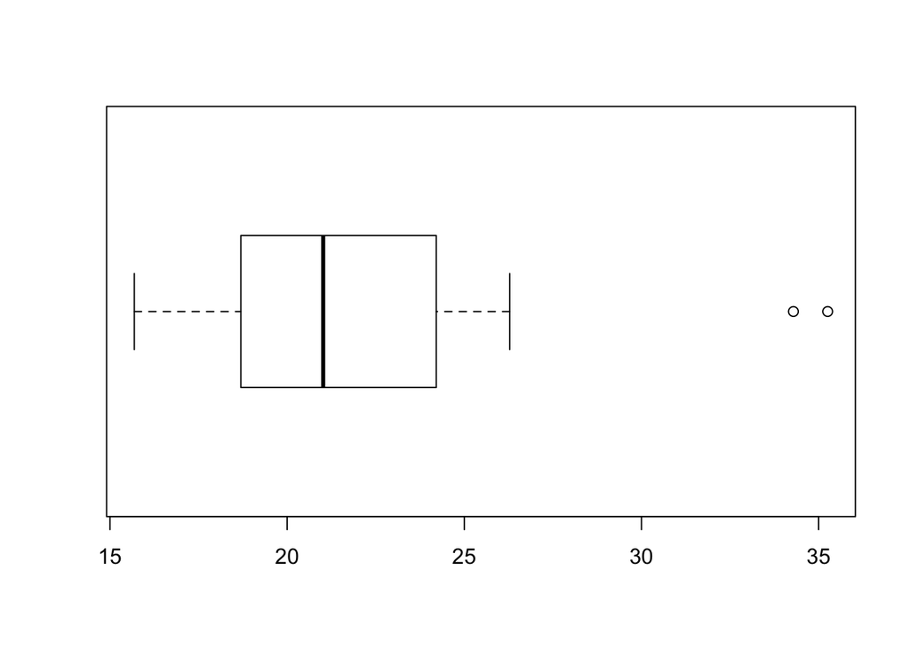

```r
boxplot(incongruent_DataSet, horizontal=TRUE)
```

#### 5. Statistical Test

Dependent t-test

Lets print the mean for both our congruent and incongruent datasets.

```r
print(paste("congruent mean", conMean))
```

```
## [1] "congruent mean 14.05"
```

```r
print(paste("incongruent mean", inconMean))
```

```
## [1] "incongruent mean 22.02"
```

Our sample size is n = 24

What is our point estimate for congruent mean minus incongruent mean?

```r
point_estimate = round((conMean - inconMean),2 )
print(paste("Our point estimate is:", point_estimate))
```

```
## [1] "Our point estimate is: -7.97"
```

Now we need the difference between the congruent and incongruent tests results. We can simply create a new column in our dataset with the results.  
We’ll print the results below.

```r
con <- congruent_DataSet
incon <- incongruent_DataSet
df["difference"] <- round((con - incon), 3)
diff = df$difference
print(paste(diff))
```

```
##  [1] "-7.199"  "-1.95"   "-11.65"  "-7.057"  "-8.134"  "-8.64"   "-9.88"
##  [8] "-8.407"  "-11.361" "-11.802" "-2.196"  "-3.346"  "-2.437"  "-3.401"
## [15] "-17.055" "-10.028" "-6.644"  "-9.79"   "-6.081"  "-21.919" "-10.95"
## [22] "-3.727"  "-2.348"  "-5.153"
```

Now lets subtract the difference from our point estimate and square our results. We’ll print the results below.

```r
df["diff_minus_pointEstimate_squared"] <- ((diff - point_estimate)^2)
print(paste(round(df$diff_minus_pointEstimate_squared, 3)))
```

```
##  [1] "0.594"   "36.24"   "13.542"  "0.834"   "0.027"   "0.449"   "3.648"
##  [8] "0.191"   "11.499"  "14.684"  "33.339"  "21.381"  "30.614"  "20.876"
## [15] "82.537"  "4.235"   "1.758"   "3.312"   "3.568"   "194.575" "8.88"
## [22] "18.003"  "31.607"  "7.935"
```

Now we will take the figures from the cell above (and our new column in dataframe) and divide it by n-1.

```r
a = sum(df$diff_minus_pointEstimate_squared)/(24-1)
print(paste(round(a, 2)))
```

```
## [1] "23.67"
```

Let’s now get the square root.

```r
b = sqrt(a)
print(paste(round(b, 2)))
```

```
## [1] "4.86"
```

Our sample standard deviation of the differences is 4.86. Now lets calculate the t-statistic.

```r
s = (-7.97) / (4.86 / sqrt(24))
print(paste("s =", round(s, 2)))
```

```
## [1] "s = -8.03"
```

Is there a significant difference between congruent and incongruent response times at an alpha level of 0.05? What are the t-critical values?

We will now calculate the effect size measure with Cohen’s d.

```r
cd <- -7.97 / -8.03
print(paste("Cohens d", round(cd, 3)))
```

```
## [1] "Cohens d 0.993"
```

What is our confidence interval?

```r
t_critical <- 2.069
ci_min <- (point_estimate) - (t_critical*(s/sqrt(24)))
ci_max <- (point_estimate) + (t_critical*(s/sqrt(24)))
print(paste("CI", round(ci_min, 2),",", round(ci_max, 2)))
```

```
## [1] "CI -4.58 , -11.36"
```